# **Gráficos con ggplot2**

### 0.7.3 Guardar ggplots

Los ggplots pueden exportarse como archivos de imagen utilizando la función `ggsave`:

**Código**

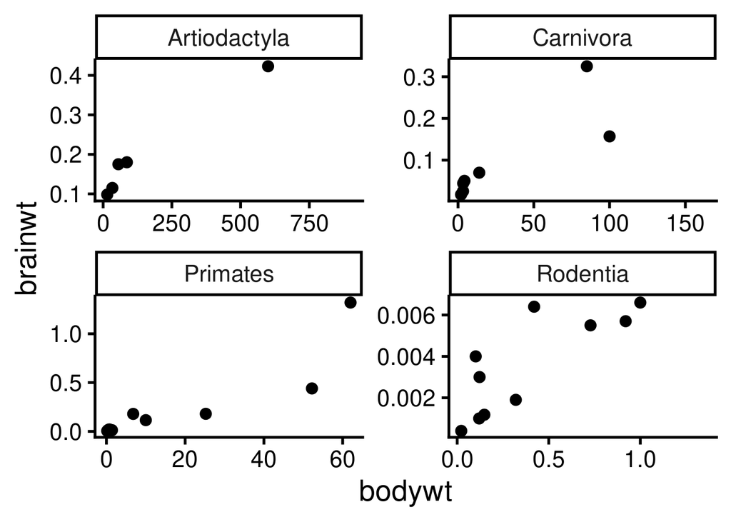

```r
ggplot(
  data = msleep[msleep$order %in% names(tab)[tab > 5], ],
  mapping = aes(x = bodywt, y = brainwt)
) +
  geom_point() +
  facet_wrap(~order, scales = "free")
```

**Código**

```r
# Export
ggsave("plot.png", width = 5, height = 5)
```

El tipo de archivo de imagen se identificará por la extensión en el nombre del archivo

Personalización adicional del eje:

**Código**

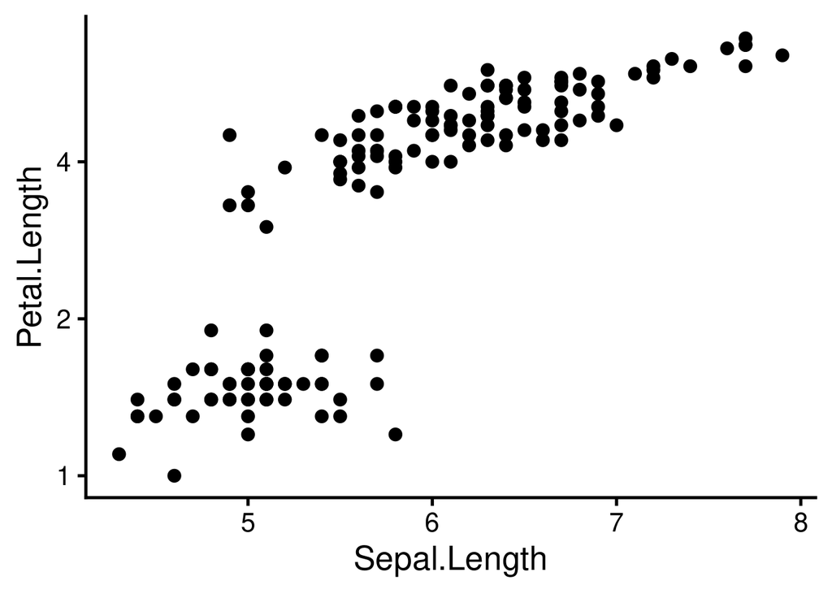

```r
# Log2 scaling of the y axis (with visually-equal spacing)
require(scales)

p + scale_y_continuous(trans = log2_trans())
```

**Código**

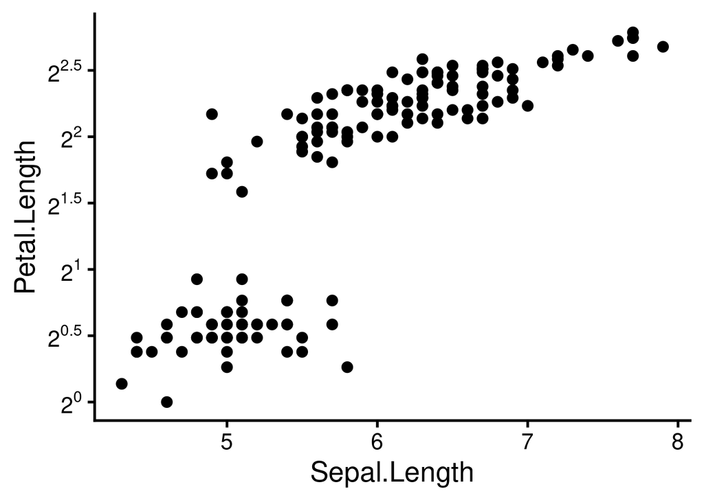

```r
# show exponents
p + scale_y_continuous(
  trans = log2_trans(),
  breaks = trans_breaks("log2", function(x) 2^x),
  labels = trans_format("log2", math_format(2^.x))
)
```

**Código**

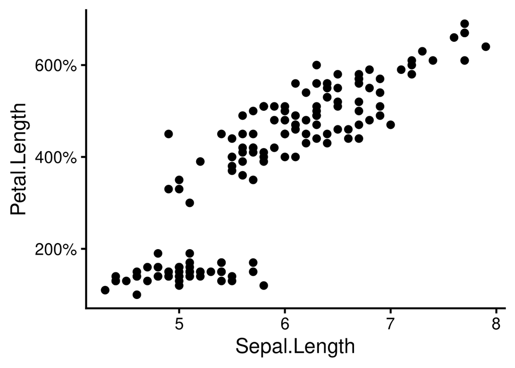

```r
# Percent
p + scale_y_continuous(labels = percent)
```

**Código**

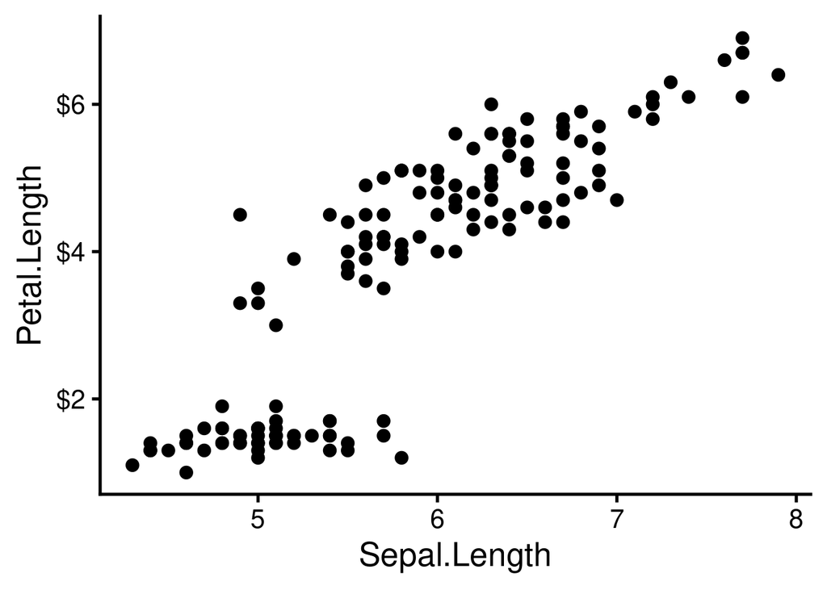

```r
# dollar
p + scale_y_continuous(labels = dollar)
```

**Código**

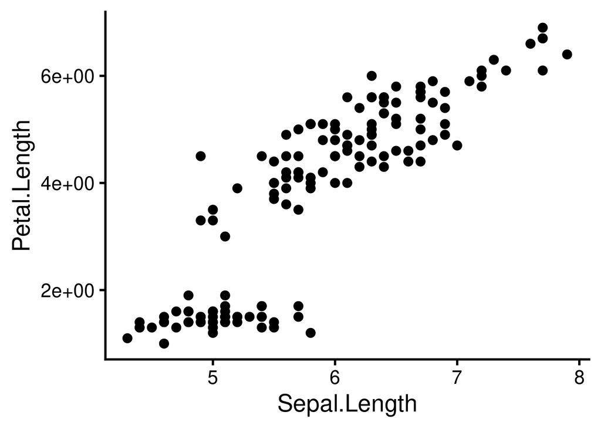

```r
# scientific
p + scale_y_continuous(labels = scientific)
```

**Código**

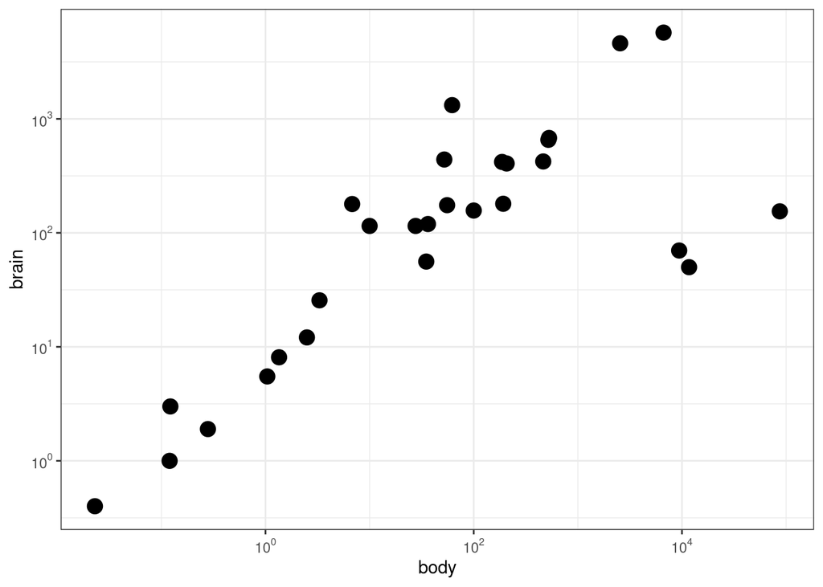

```r
### Agregar "tick marks" ###

# Cargar librerías
library(MASS)

data(Animals)

# x and y axis are transformed and formatted
p2 <- ggplot(Animals, aes(x = body, y = brain)) +
  geom_point(size = 4) +
  scale_x_log10(
    breaks = trans_breaks("log10", function(x) 10^x),
    labels = trans_format("log10", math_format(10^.x))
  ) +
  scale_y_log10(
    breaks = trans_breaks("log10", function(x) 10^x),
    labels = trans_format("log10", math_format(10^.x))
  ) +
  theme_bw()

# log-log plot without log tick marks
p2
```

**Código**

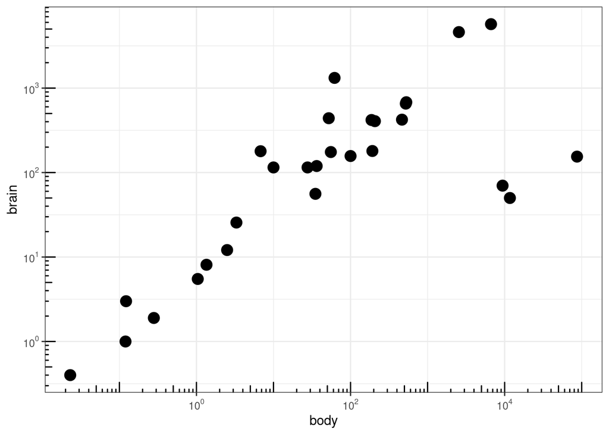

```r
# Show log tick marks
p2 + annotation_logticks()
```

**Código**

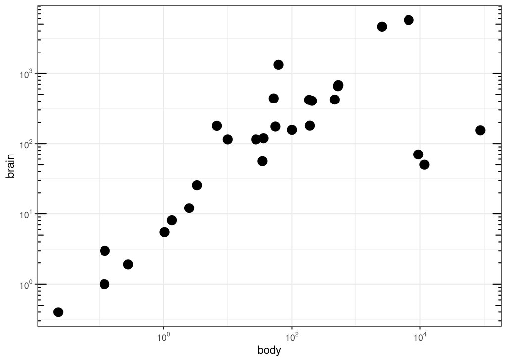

```r
# # Log ticks on left and right
p2 + annotation_logticks(sides = "lr")
```

**Código**

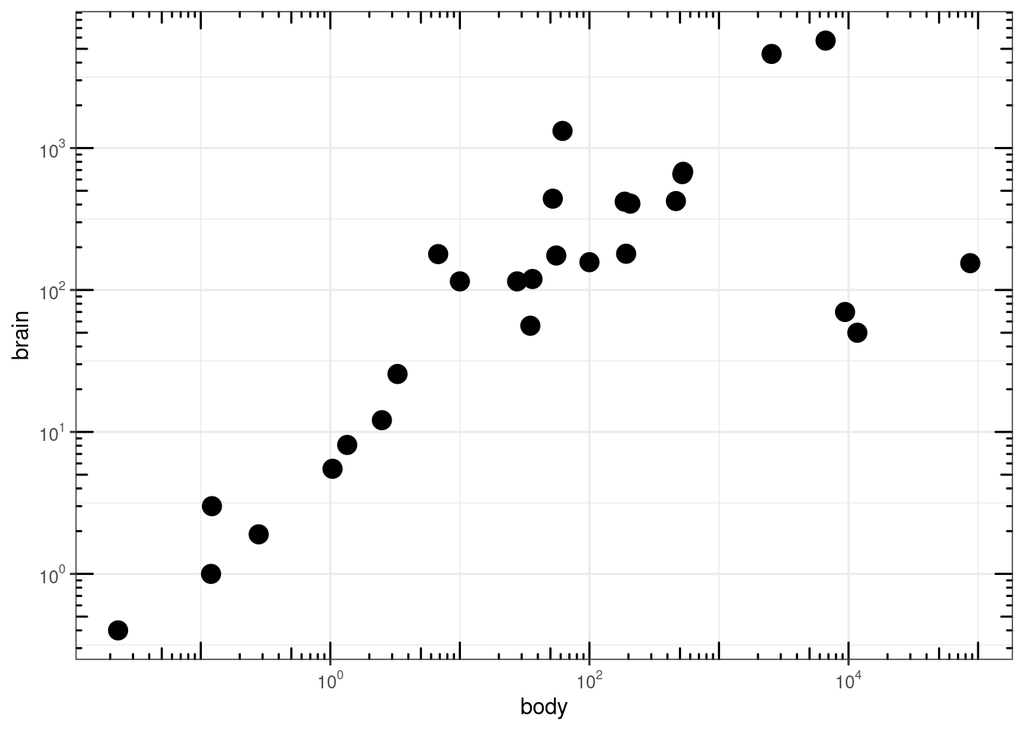

```r
# All sides
p2 + annotation_logticks(sides = "trbl")
```

### 0.7.4 Otros gráficos

Se pueden generar muchos otros tipos de gráficos. Aquí muestro un ejemplo de gráficos de contorno y de “mapa de calor”:

**Código**

```r
head(faithful)
```

| eruptions | waiting |
| --- | --- |
| 3.600 | 79 |
| 1.800 | 54 |
| 3.333 | 74 |
| 2.283 | 62 |
| 4.533 | 85 |
| 2.883 | 55 |

**Código**

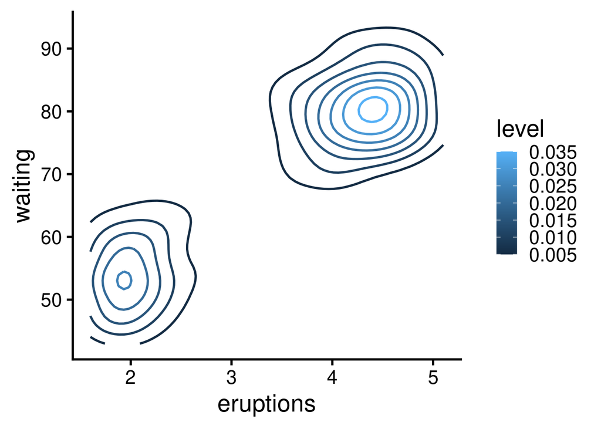

```r
ggplot(faithfuld, aes(eruptions, waiting)) +
  geom_contour(aes(z = density, colour = after_stat(level)))
```

**Código**

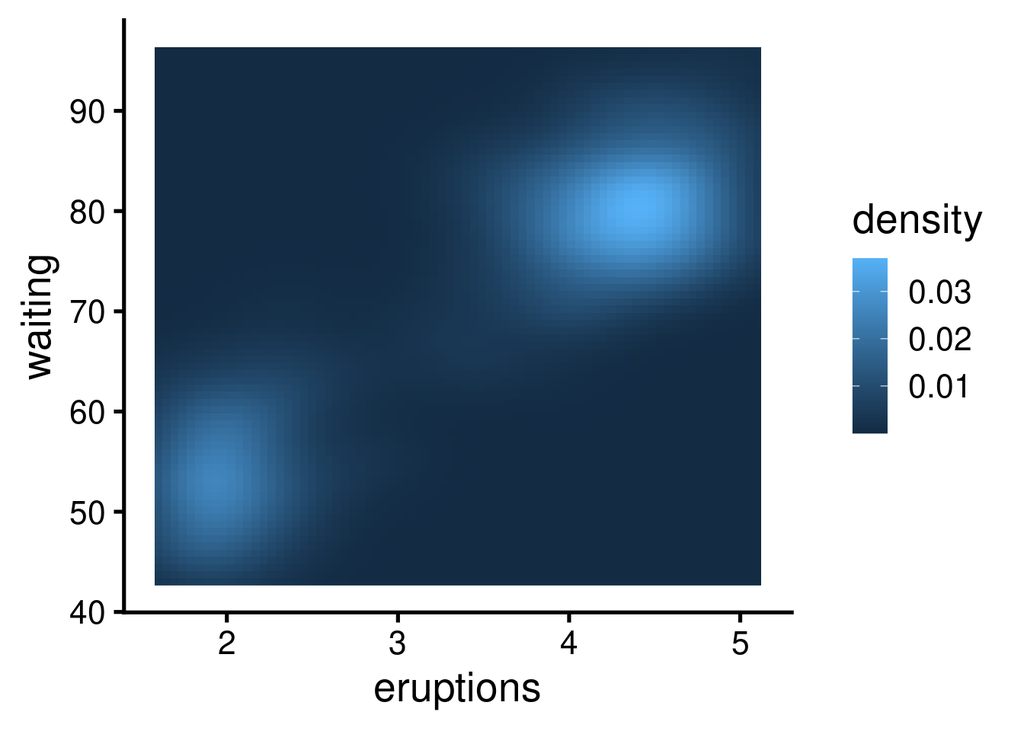

```r
ggplot(faithfuld, aes(eruptions, waiting)) +
  geom_raster(aes(fill = density))
```

## 0.8 Otros paquetes de gráficos en R

Consulte la [CRAN Graphics Task View](http://cran.r-project.org/web/views/Graphics.html) para obtener una lista más completa de herramientas gráficas en **R**.

## 0.9 References

- Lemon J (2006) Plotrix: a package in the red light district of R. R-News 6(4):8–12
- Warnes GR, Bolker B, Bonebakker L, Gentleman R, Liaw WHA, Lumley T, Maechler M, Magnusson A, Moeller S, Schwartz M, Venables B (2015) gplots: various R programming tools for plotting data. R package version 2.17.0. https://CRAN.R-project.org/package=gplots
- Wickham H (2010) A layered grammar of graphics. J Comput Graph Stat 19(1):3–28
- Wilkinson L (2005) The grammar of graphics. Statistics and computing, 2nd edn. Springer, New York